[figure not shown]

# Lostine River Weir Steelhead Update

Brian Simmons

2023-06-27

### Disposition & Capture Summary

- The Lostine River weir started operating on March 1, 2023 and captured the first steelhead of the year on April 1, 2023.
- The weir has operated continuously except from 9:00 PM on May 2 to 7:00 AM on May 5, and 9:00 PM on May 17 to 8:00 AM on May 24, 2023 when it was inoperable due to high flows and debris.
- There is no supplementation program for Lostine River steelhead. However, this report shows all possible dispositions of fish captured at the Lostine River weir to remain consistent across different reporting species.

Table 1. Return year 2023 capture and disposition summary of hatchery steelhead (Numbers in parentheses exclude recaptures).

| Disposition | F | M | Total [all] |
| --- | --- | --- | --- |
| Upstream Release | 0 (0) | 1 (1) | 1 (1) |
| Brood Collection | 0 (0) | 0 (0) | 0 (0) |
| Food Distribution | 0 (0) | 0 (0) | 0 (0) |
| Wallowa River Outplant | 0 (0) | 0 (0) | 0 (0) |
| Recycled to Fishery | 0 (0) | 0 (0) | 0 (0) |
| Mortality | 0 (0) | 0 (0) | 0 (0) |
| Total | 0 (0) | 1 (1) | 1 (1) |

Table 2. Return year 2023 capture and disposition summary of natural steelhead (Numbers in parentheses exclude recaptures).

| Disposition | F | M | Total [all] |
| --- | --- | --- | --- |
| Upstream Release | 15 (15) | 12 (12) | 27 (27) |
| Brood Collection | 0 (0) | 0 (0) | 0 (0) |
| Food Distribution | 0 (0) | 0 (0) | 0 (0) |
| Wallowa River Outplant | 0 (0) | 0 (0) | 0 (0) |
| Recycled to Fishery | 0 (0) | 0 (0) | 0 (0) |
| Mortality | 0 (0) | 0 (0) | 0 (0) |
| Total | 15 (15) | 12 (12) | 27 (27) |

Table 3. Return year 2023 weekly summary of captured steelhead and Rainbow Trout, excluding recaptures. *Asterisk indicates an incomplete week.

| Week Start | Natural Steelhead | Hatchery Steelhead | Rainbow Trout |
| --- | --- | --- | --- |
| Mar 26 | 2 | 0 | 0 |
| Apr 02 | 1 | 0 | 1 |
| Apr 16 | 8 | 1 | 0 |
| Apr 23 | 14 | 0 | 0 |
| Apr 30* | 2 | 0 | 0 |
| Total | 27 | 1 | 1 |

### Current Arrival & Annual Run Timing

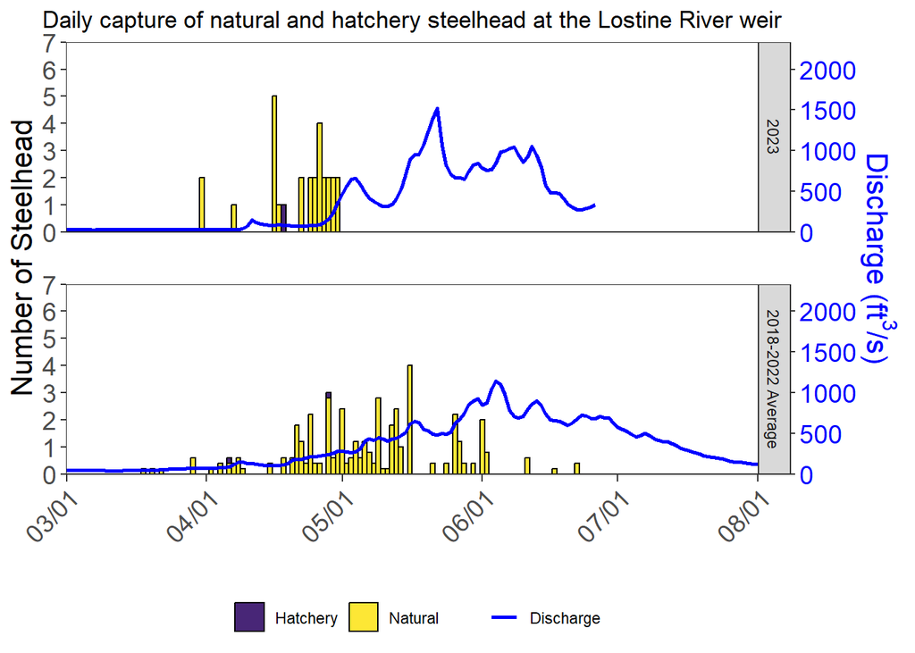

Figure 1. Return year 2023 (top panel) and five-year average (bottom panel) of mean daily discharge (cubic feet per second) and daily captures of hatchery- and natural-origin Steelhead at the Lostine River Weir. Discharge recorded at USGS station 1333000 located upstream of the town of Lostine.

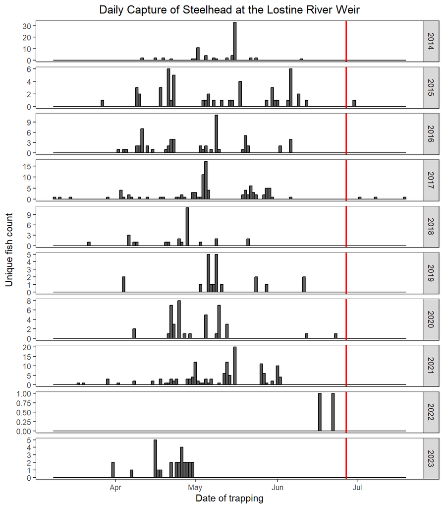

Figure 2. Daily capture of steelhead at the Lostine River weir. The red vertical line idicates current day of year.

Table 4. 10-year arrival timing of steelhead at the Lostine River Weir.

| Year | Unique Fish | First Capture | 10th Percentile | Median | 90th Percentile | Final Capture |
| --- | --- | --- | --- | --- | --- | --- |
| 2014 | 71 | Apr 12 | May 01 | May 17 | May 17 | Jun 11 |
| 2015 | 50 | Mar 28 | Apr 11 | May 08 | Jun 07 | Jul 01 |
| 2016 | 60 | Apr 03 | Apr 11 | May 04 | May 23 | Jun 07 |
| 2017 | 97 | Mar 10 | Apr 07 | May 06 | May 29 | Jul 20 |
| 2018 | 27 | Mar 23 | Apr 07 | Apr 29 | May 10 | May 22 |
| 2019 | 21 | Apr 05 | May 04 | May 10 | May 29 | Jun 12 |
| 2020 | 41 | Apr 09 | Apr 23 | Apr 26 | May 14 | Jun 24 |
| 2021 | 134 | Mar 19 | Apr 21 | May 14 | Jun 01 | Jun 03 |
| 2022 | 2 | Jun 18 | Jun 18 | Jun 20 | Jun 22 | Jun 23 |
| 2023 | 28 | Apr 01 | Apr 14 | Apr 25 | Apr 30 | May 01 |

**Distribution List**

Beals, S (ODFW)  
Brady, A (BPA)  
Brandt, E (ODFW)  
Bratcher, K (ODFW)  
Brigante, E (ODFW)  
Bronson, P (CTUIR)  
Craft, N (ODFW)  
Deal, D (ODFW)  
Engle, R (FWS)  
Farnam, B (NOAA)  
Feldhaus, J (ODFW)  
Flesher, M (ODFW)  
Garza, Gabriel (ODFW)  
Gee, S (ODFW)  
Gibbs, A (ODFW)  
Greiner, M (ODFW)  
Hagenah, P (Wallowa CTY)  
Harbeck, J (NPT)  
Harrod, R (ODFW)  
Hesse, J (NPT)  
Humphreys, J (TU)  
Johnson, B (NPT)

Johnson, D (NPT)  
Kozlowski, C (ODFW)  
Lovrak, J (CTUIR)  
Lance, M (ODFW)  
Lemanski, J (ODFW)  
Maxwell, A (TU)  
McLean, M (CTUIR)  
McOmie, E (BPA)  
Nisbitt, K (Wallowa CTY)  
Oatman, J (NPT)  
Robertson, M (FWS)  
Rumelhart, R (NPT)  
Treadway, E (ODFW)  
Smith, J (ODFW)  
Vatland, S (NPT)  
Vogel, J (NPT)  
Watry, C (NPT)  
Wiese, N (USFWS)  
Wolfe, W (Landowner)  
Yanke, J (ODFW)  
Yearout, J (NPT)  
Young, B (NPT)  
Zollman, R (NPT)

**Please direct questions regarding content of this report to:**  
**Brian Simmons**  
Grande Ronde Supplemenetation Monitoring and Evalutation  
Fisheries Biologist II  
541-432-2515  
brians@nezperce.org  
or  
**Shane Vatland**  
Grand Ronde Supplementation Monitoring and Evaluation  
Project Leader  
541-432-2508  
shanev@nezperce.org  
**Nez Perce Tribe**  
Joseph Field Office  
500 North Main Street  
P.O.Box 909  
Joseph, OR 97846